# Graded Novelty Encoding Task - pilot - RUN 2 Analysis

# The study

### Familiarization phase

Participants see 5 stimuli repeated 8 times each. Stimuli consist of a 3x3 grid, with 5 random shapes (circle,triangle,square) placed randomly (any 9 cells) with random color (red,blue,yellow,green,orange,purple).

### Study phase

Participants see the 5 familiar stimuli 5 times each (25) and 50 novel stimuli. They have to judge if the current stimulus is one of the familiars. The novels differ to a differing degree from the familiars: there is 5x2 (two for each familiar) that is wholly different (diffarr). 5x2 that has the same placement of random shapes (sarr), 5x2 same arrangement and shapes (sarrsha), 5x2 same arrangement and colors (sarrcol) 5x2 same arrangement, shapes and colors (colors are randomized, thus, these are not the same as the familiars - sarrshacol).

### Test phase

Participants see the novels from the study phase and 50 new stimuli (sarr - 10, sarrsha - 10, etc.). Participants have to signal if they have already seen the current stimulus or it is wholly new. They had the option to signal “maybe”, but were asked to do this in moderation (maybe resp <= 20). These responses have been added to correct responses.

## Participants

The task was completed by a total of 75 participants.

We also excluded some (3) participants as they missed more than 66 trials.

We also excluded those who recognized less than half of the prototypes in the study phase (16).

## Study phase:

During the study phase, the participants see familiar and novel items.

The sample produced a mean (±sd) recognition rate of 8.3333333 ± 7.2371673 for familiar pictures.

The sample performed above chance levels, as a one sample t-test showed (t(131)=12.435549, p = 6.278203310^{-24}, Cohen’s d = 1.0823756, 95% CI:0.7136547 - 1.4510965).

We use an ANOVA to see if there is a difference in correct rejection for the different novels.

```
## Anova Table (Type 3 tests)
##
## Response: N
##   Effect           df  MSE         F  ges p.value
## 1   type 3.67, 157.83 1.84 14.13 *** .100   <.001
## ---
## Signif. codes:  0 '***' 0.001 '**' 0.01 '*' 0.05 '+' 0.1 ' ' 1
##
## Sphericity correction method: GG
```

```
##  contrast             estimate    SE  df t.ratio p.value
##  diffarr - sarr         1.0000 0.277 172  3.605  0.0037
##  diffarr - sarrcol      0.8636 0.277 172  3.114  0.0182
##  diffarr - sarrsha      2.0682 0.277 172  7.456  <.0001
##  diffarr - sarrshacol   0.8409 0.277 172  3.032  0.0232
##  sarr - sarrcol        -0.1364 0.277 172 -0.492  0.9881
##  sarr - sarrsha         1.0682 0.277 172  3.851  0.0015
##  sarr - sarrshacol     -0.1591 0.277 172 -0.574  0.9788
##  sarrcol - sarrsha      1.2045 0.277 172  4.343  0.0002
##  sarrcol - sarrshacol  -0.0227 0.277 172 -0.082  1.0000
##  sarrsha - sarrshacol  -1.2273 0.277 172 -4.425  0.0002
##
## P value adjustment: tukey method for comparing a family of 5 estimates
```

```
##  contrast  estimate    SE  df t.ratio p.value
##  linear       -2.75 0.620 172 -4.434  <.0001
##  quadratic     3.11 0.734 172  4.243  <.0001
##  cubic         1.30 0.620 172  2.089  0.0382
##  quartic       6.25 1.641 172  3.809  0.0002
```

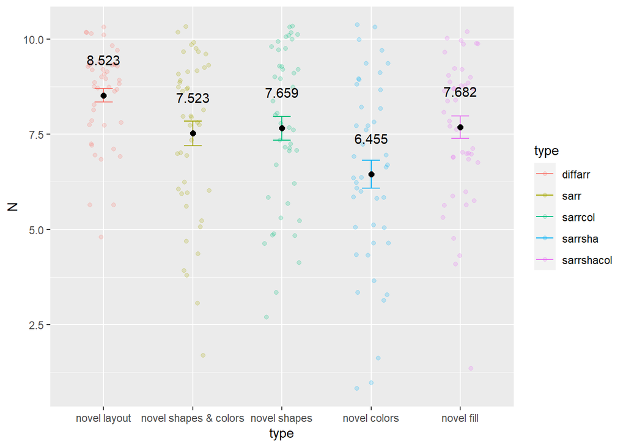

## Test phase:

```
## [1] "A t-test to compare the number of old responses btwn old and new stim"
```

```
##
##  Paired t-test
##
## data:  a and b
## t = 3.6766, df = 219, p-value = 0.0002974
## alternative hypothesis: true difference in means is not equal to 0
## 95 percent confidence interval:
##  0.2277531 0.7540651
## sample estimates:
## mean of the differences
##               0.4909091
```

```
##
## Cohen's d
##
## d estimate: 0.2346264 (small)
## 95 percent confidence interval:
##     lower     upper
## 0.1074870 0.3617659
```

```
##
##  Shapiro-Wilk normality test
##
## data:  d
## W = 0.96666, p-value = 4.791e-05
```

```
## [1] "ANOVA with correct recognition minus false alarm by category"
```

```
## Anova Table (Type 3 tests)
##
## Response: CorrRecog
##   Effect           df  MSE      F  ges p.value
## 1   type 3.33, 143.05 4.30 3.65 * .061    .011
## ---
## Signif. codes:  0 '***' 0.001 '**' 0.01 '*' 0.05 '+' 0.1 ' ' 1
##
## Sphericity correction method: GG
```

```
##  contrast             estimate    SE  df t.ratio p.value
##  diffarr - sarr         -0.545 0.403 172 -1.353  0.6582
##  diffarr - sarrcol       0.545 0.403 172  1.353  0.6582
##  diffarr - sarrsha       0.182 0.403 172  0.451  0.9914
##  diffarr - sarrshacol    0.886 0.403 172  2.199  0.1849
##  sarr - sarrcol          1.091 0.403 172  2.707  0.0570
##  sarr - sarrsha          0.727 0.403 172  1.805  0.3743
##  sarr - sarrshacol       1.432 0.403 172  3.553  0.0044
##  sarrcol - sarrsha      -0.364 0.403 172 -0.902  0.8957
##  sarrcol - sarrshacol    0.341 0.403 172  0.846  0.9158
##  sarrsha - sarrshacol    0.705 0.403 172  1.748  0.4075
##
## P value adjustment: tukey method for comparing a family of 5 estimates
```

```
##  contrast  estimate    SE  df t.ratio p.value
##  linear      -2.500 0.901 172 -2.774  0.0061
##  quadratic   -1.045 1.066 172 -0.980  0.3282
##  cubic        0.568 0.901 172  0.630  0.5292
##  quartic     -5.614 2.384 172 -2.354  0.0197
```

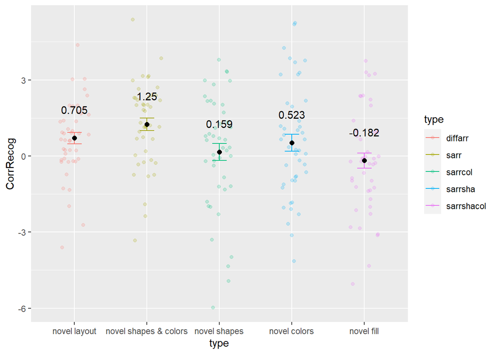

```
## [1] "ANOVA with correct rejection minus false alarm by category"
```

```
## Anova Table (Type 3 tests)
##
## Response: CorrRejec
##   Effect           df  MSE      F  ges p.value
## 1   type 3.87, 166.42 4.03 3.08 * .049    .019
## ---
## Signif. codes:  0 '***' 0.001 '**' 0.01 '*' 0.05 '+' 0.1 ' ' 1
##
## Sphericity correction method: GG
```

```
##  contrast             estimate    SE  df t.ratio p.value
##  diffarr - sarr         -0.114 0.421 172 -0.270  0.9988
##  diffarr - sarrcol       0.295 0.421 172  0.702  0.9559
##  diffarr - sarrsha       0.864 0.421 172  2.051  0.2466
##  diffarr - sarrshacol    1.068 0.421 172  2.536  0.0874
##  sarr - sarrcol          0.409 0.421 172  0.971  0.8677
##  sarr - sarrsha          0.977 0.421 172  2.321  0.1434
##  sarr - sarrshacol       1.182 0.421 172  2.806  0.0438
##  sarrcol - sarrsha       0.568 0.421 172  1.349  0.6608
##  sarrcol - sarrshacol    0.773 0.421 172  1.835  0.3570
##  sarrsha - sarrshacol    0.205 0.421 172  0.486  0.9886
##
## P value adjustment: tukey method for comparing a family of 5 estimates
```

```
##  contrast  estimate    SE  df t.ratio p.value
##  linear      -3.114 0.942 172 -3.307  0.0012
##  quadratic   -0.795 1.114 172 -0.714  0.4762
##  cubic        0.886 0.942 172  0.941  0.3479
##  quartic      0.159 2.491 172  0.064  0.9492
```

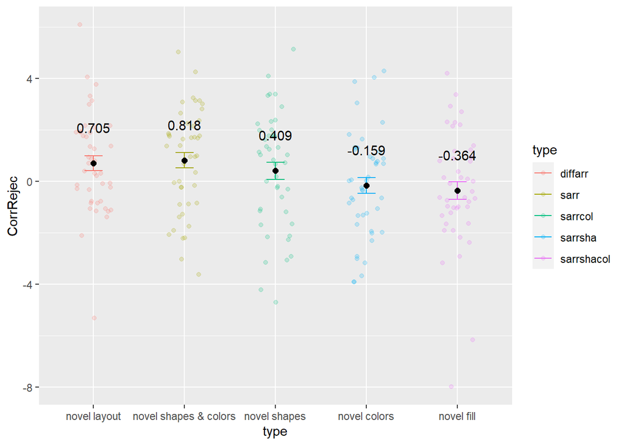

```
## [1] "ANOVA with corrected differentiation score by category ((crecog-fa)+(creject-fa))"
```

```
## Anova Table (Type 3 tests)
##
## Response: OverallCCat
##   Effect           df   MSE      F  ges p.value
## 1   type 3.73, 160.38 13.47 3.53 * .056    .010
## ---
## Signif. codes:  0 '***' 0.001 '**' 0.01 '*' 0.05 '+' 0.1 ' ' 1
##
## Sphericity correction method: GG
```

```
##  contrast             estimate    SE  df t.ratio p.value
##  diffarr - sarr         -0.659 0.756 172 -0.872  0.9067
##  diffarr - sarrcol       0.841 0.756 172  1.113  0.7996
##  diffarr - sarrsha       1.045 0.756 172  1.384  0.6391
##  diffarr - sarrshacol    1.955 0.756 172  2.587  0.0773
##  sarr - sarrcol          1.500 0.756 172  1.985  0.2777
##  sarr - sarrsha          1.705 0.756 172  2.256  0.1646
##  sarr - sarrshacol       2.614 0.756 172  3.459  0.0061
##  sarrcol - sarrsha       0.205 0.756 172  0.271  0.9988
##  sarrcol - sarrshacol    1.114 0.756 172  1.474  0.5809
##  sarrsha - sarrshacol    0.909 0.756 172  1.203  0.7496
##
## P value adjustment: tukey method for comparing a family of 5 estimates
```

```
##  contrast  estimate   SE  df t.ratio p.value
##  linear       -5.61 1.69 172 -3.322  0.0011
##  quadratic    -1.84 2.00 172 -0.921  0.3584
##  cubic         1.45 1.69 172  0.861  0.3905
##  quartic      -5.45 4.47 172 -1.220  0.2241
```

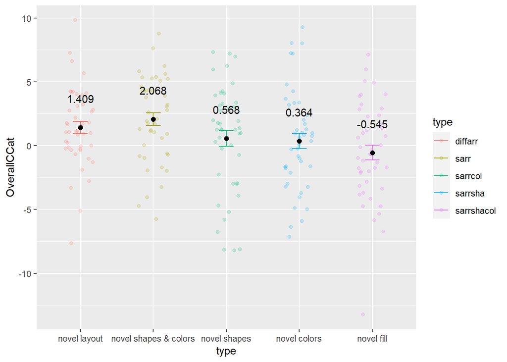

# Mixed models

```
## Install package "strengejacke" from GitHub (`devtools::install_github("strengejacke/strengejacke")`) to load all sj-packages at once!
```

```
## Generalized linear mixed model fit by maximum likelihood (Laplace
##   Approximation) [glmerMod]
##  Family: binomial  ( logit )
## Formula: rt_resp_old0 ~ type * tq + (1 | workerId)
##    Data: tdlmm
##
##      AIC      BIC   logLik deviance df.resid
##   4339.7   4407.7  -2158.9   4317.7     3565
##
## Scaled residuals:
##     Min      1Q  Median      3Q     Max
## -3.4278 -0.9263  0.4423  0.7629  1.9476
##
## Random effects:
##  Groups   Name        Variance Std.Dev.
##  workerId (Intercept) 0.3974   0.6304
## Number of obs: 3576, groups:  workerId, 44
##
## Fixed effects:
##                      Estimate Std. Error z value Pr(>|z|)
## (Intercept)            1.7584     0.1729  10.172  < 2e-16 ***
## typesarr              -0.4102     0.1951  -2.103  0.03546 *
## typesarrcol           -1.2980     0.1812  -7.163 7.87e-13 ***
## typesarrsha           -1.7155     0.1854  -9.255  < 2e-16 ***
## typesarrshacol        -1.9000     0.1833 -10.365  < 2e-16 ***
## tqold                 -0.5444     0.1896  -2.871  0.00409 **
## typesarr:tqold        -0.1576     0.2571  -0.613  0.53993
## typesarrcol:tqold      0.4031     0.2456   1.642  0.10067
## typesarrsha:tqold      0.4304     0.2488   1.730  0.08359 .
## typesarrshacol:tqold   0.6750     0.2474   2.728  0.00637 **
## ---
## Signif. codes:  0 '***' 0.001 '**' 0.01 '*' 0.05 '.' 0.1 ' ' 1
##
## Correlation of Fixed Effects:
##             (Intr) typesrr typsrrc typesrrsh typsrrshc tqold  typsrr:t typsrrc:
## typesarr    -0.611
## typesarrcol -0.662  0.583
## typesarrsha -0.649  0.570   0.617
## typesrrshcl -0.657  0.576   0.625   0.612
## tqold       -0.630  0.556   0.600   0.587     0.594
## typsrr:tqld  0.463 -0.758  -0.442  -0.432    -0.437    -0.737
## typsrrcl:tq  0.486 -0.430  -0.736  -0.453    -0.458    -0.772  0.569
## typsrrsh:tq  0.480 -0.424  -0.458  -0.742    -0.453    -0.762  0.562    0.588
## typsrrshcl:  0.483 -0.426  -0.460  -0.450    -0.737    -0.767  0.565    0.592
##             typsrrsh:t
## typesarr
## typesarrcol
## typesarrsha
## typesrrshcl
## tqold
## typsrr:tqld
## typsrrcl:tq
## typsrrsh:tq
## typsrrshcl:  0.584
```

```
## Package `effects` is not available, but needed for `ggeffect()`. Either install package `effects`, or use `ggpredict()`. Calling `ggpredict()` now.FALSE
```

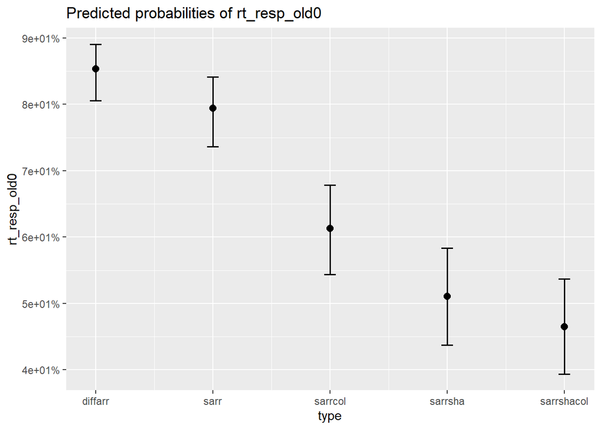

```
## Package `effects` is not available, but needed for `ggeffect()`. Either install package `effects`, or use `ggpredict()`. Calling `ggpredict()` now.FALSE
```

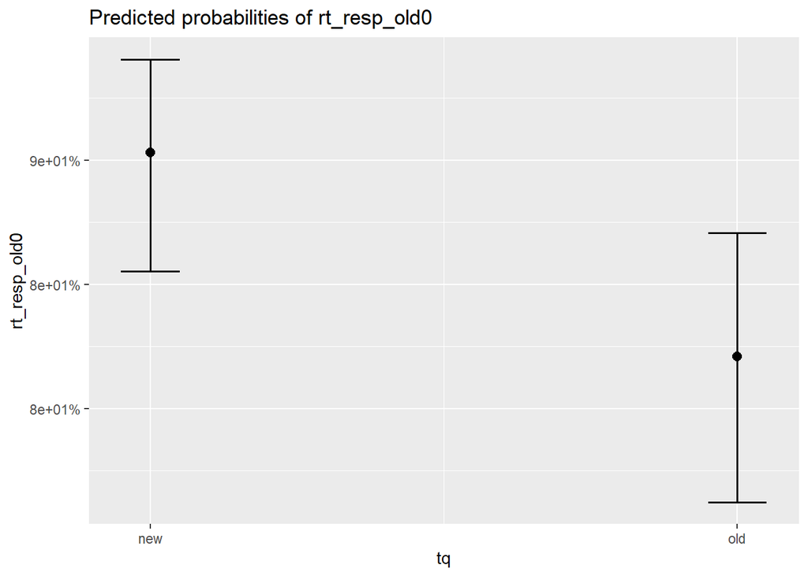

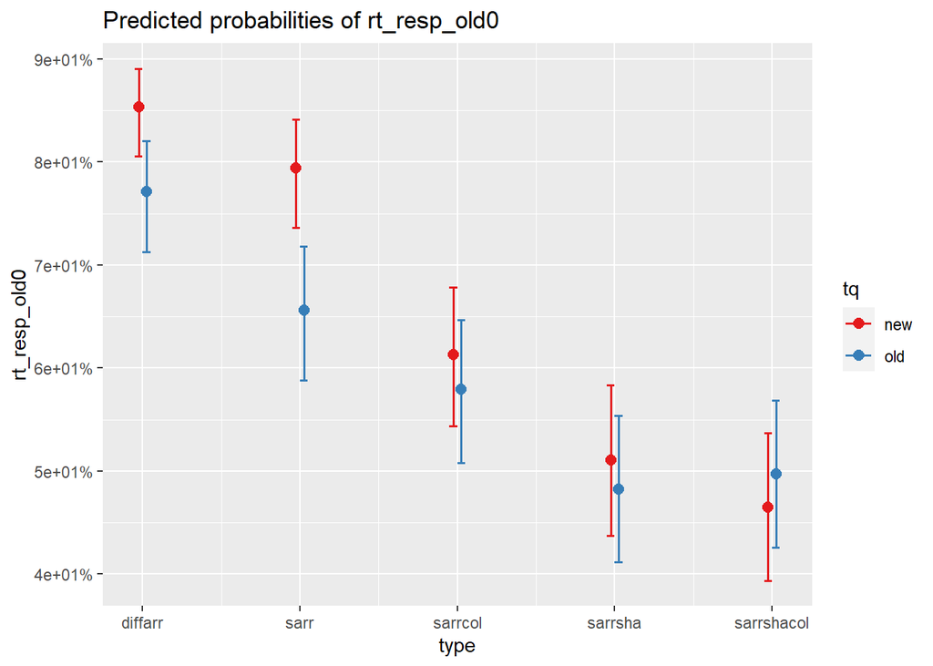

```
## Generalized linear mixed model fit by maximum likelihood (Laplace
##   Approximation) [glmerMod]
##  Family: binomial  ( logit )
## Formula: rt_resp_old0 ~ DTF * tq + (1 | workerId)
##    Data: tdlmm
##
##      AIC      BIC   logLik deviance df.resid
##   4396.0   4426.9  -2193.0   4386.0     3571
##
## Scaled residuals:
##     Min      1Q  Median      3Q     Max
## -4.4799 -0.9553  0.4651  0.7795  1.7470
##
## Random effects:
##  Groups   Name        Variance Std.Dev.
##  workerId (Intercept) 0.3776   0.6145
## Number of obs: 3576, groups:  workerId, 44
##
## Fixed effects:
##             Estimate Std. Error z value Pr(>|z|)
## (Intercept) -0.18628    0.13041  -1.428  0.15318
## DTF          0.12404    0.01235  10.045  < 2e-16 ***
## tqold        0.04721    0.12324   0.383  0.70166
## DTF:tqold   -0.04221    0.01603  -2.633  0.00846 **
## ---
## Signif. codes:  0 '***' 0.001 '**' 0.01 '*' 0.05 '.' 0.1 ' ' 1
##
## Correlation of Fixed Effects:
##           (Intr) DTF    tqold
## DTF       -0.569
## tqold     -0.521  0.602
## DTF:tqold  0.438 -0.767 -0.803
```

```
## Package `effects` is not available, but needed for `ggeffect()`. Either install package `effects`, or use `ggpredict()`. Calling `ggpredict()` now.FALSE
```

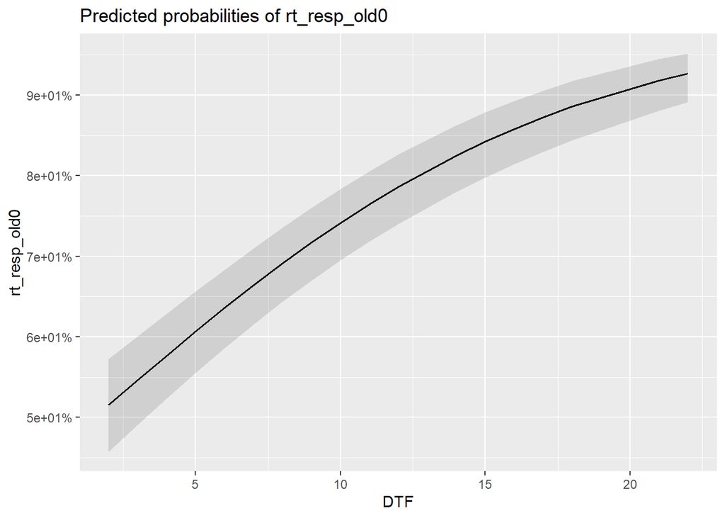

```
## Package `effects` is not available, but needed for `ggeffect()`. Either install package `effects`, or use `ggpredict()`. Calling `ggpredict()` now.FALSE
```

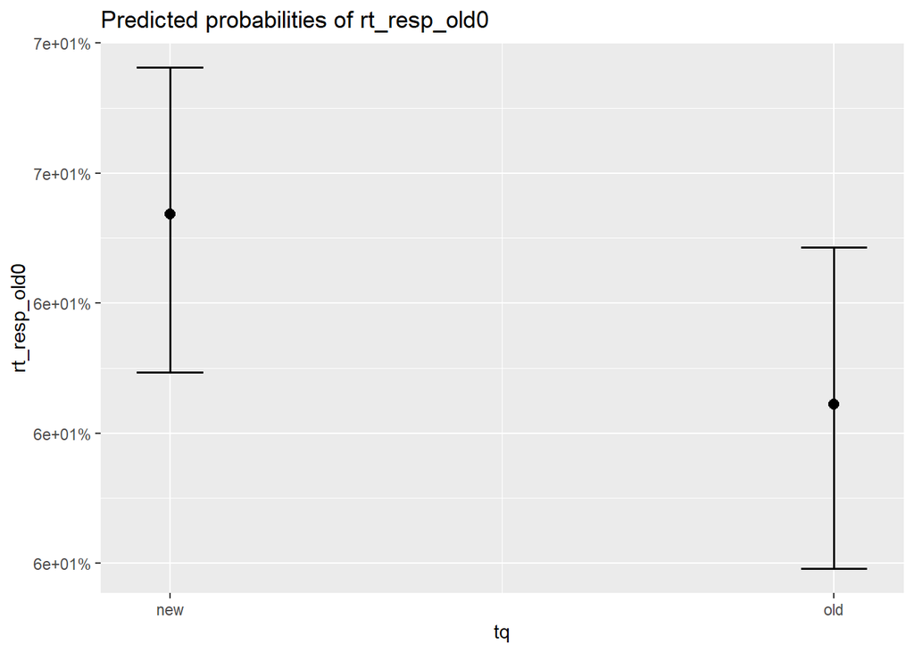

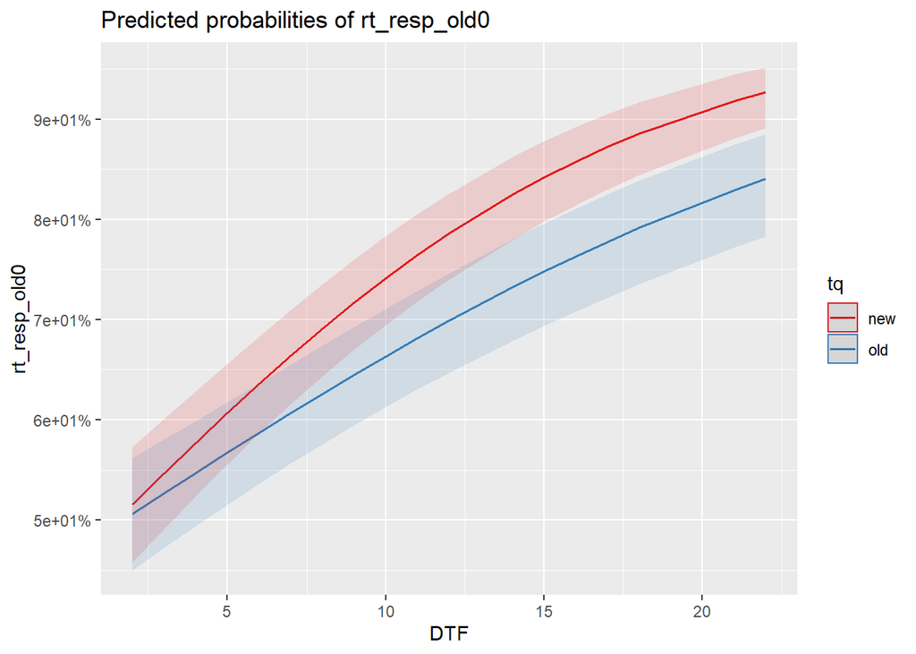

```
## Generalized linear mixed model fit by maximum likelihood (Laplace
##   Approximation) [glmerMod]
##  Family: binomial  ( logit )
## Formula: rt_resp_old0 ~ DTAF * tq + (1 | workerId)
##    Data: tdlmm
##
##      AIC      BIC   logLik deviance df.resid
##   4389.5   4420.4  -2189.7   4379.5     3571
##
## Scaled residuals:
##     Min      1Q  Median      3Q     Max
## -4.5982 -0.9509  0.4642  0.7750  1.8329
##
## Random effects:
##  Groups   Name        Variance Std.Dev.
##  workerId (Intercept) 0.3743   0.6118
## Number of obs: 3576, groups:  workerId, 44
##
## Fixed effects:
##             Estimate Std. Error z value Pr(>|z|)
## (Intercept) -2.15325    0.29028  -7.418 1.19e-13 ***
## DTAF         0.21764    0.02160  10.078  < 2e-16 ***
## tqold        0.47709    0.36887   1.293   0.1959
## DTAF:tqold  -0.05501    0.02876  -1.913   0.0558 .
## ---
## Signif. codes:  0 '***' 0.001 '**' 0.01 '*' 0.05 '.' 0.1 ' ' 1
##
## Correlation of Fixed Effects:
##            (Intr) DTAF   tqold
## DTAF       -0.930
## tqold      -0.705  0.729
## DTAF:tqold  0.696 -0.747 -0.980
## convergence code: 0
## Model failed to converge with max|grad| = 0.00526748 (tol = 0.002, component 1)
```

```
## Package `effects` is not available, but needed for `ggeffect()`. Either install package `effects`, or use `ggpredict()`. Calling `ggpredict()` now.FALSE
```

```
## Data were 'prettified'. Consider using `terms="DTAF [all]"` to get smooth plots.
```

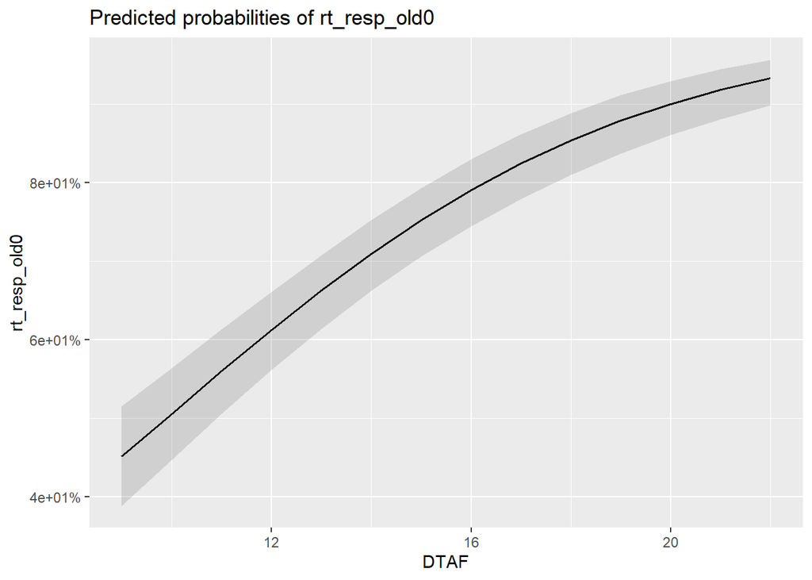

```
## Package `effects` is not available, but needed for `ggeffect()`. Either install package `effects`, or use `ggpredict()`. Calling `ggpredict()` now.FALSE
## Data were 'prettified'. Consider using `terms="DTAF [all]"` to get smooth plots.
```

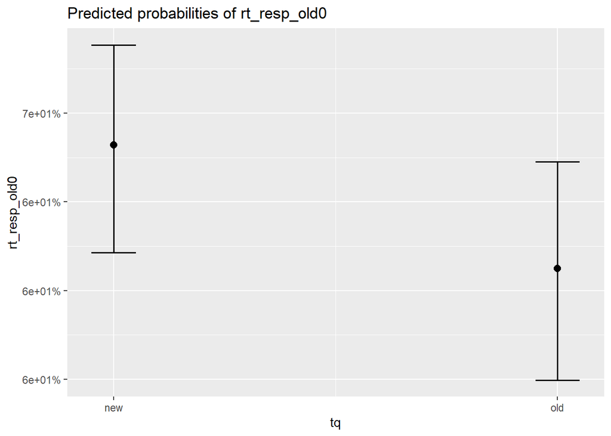

```
## Data were 'prettified'. Consider using `terms="DTAF [all]"` to get smooth plots.
```

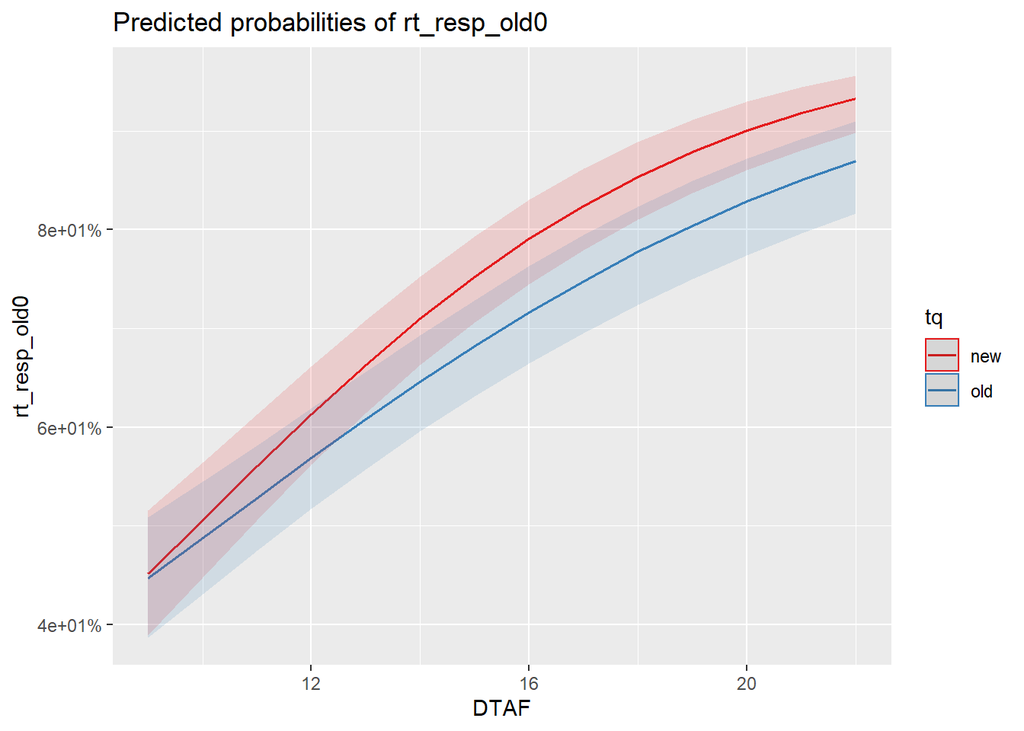

```
## Generalized linear mixed model fit by maximum likelihood (Laplace
##   Approximation) [glmerMod]
##  Family: binomial  ( logit )
## Formula: rt_resp_old0 ~ DTAN * tq + (1 | workerId)
##    Data: tdlmm
##
##      AIC      BIC   logLik deviance df.resid
##   4403.0   4433.9  -2196.5   4393.0     3571
##
## Scaled residuals:
##     Min      1Q  Median      3Q     Max
## -3.3274 -0.9363  0.4881  0.7584  1.9768
##
## Random effects:
##  Groups   Name        Variance Std.Dev.
##  workerId (Intercept) 0.3776   0.6145
## Number of obs: 3576, groups:  workerId, 44
##
## Fixed effects:
##             Estimate Std. Error z value Pr(>|z|)
## (Intercept) -3.23324    0.39647  -8.155 3.49e-16 ***
## DTAN         0.30504    0.03045  10.016  < 2e-16 ***
## tqold        0.57369    0.52657   1.089    0.276
## DTAN:tqold  -0.06481    0.04134  -1.568    0.117
## ---
## Signif. codes:  0 '***' 0.001 '**' 0.01 '*' 0.05 '.' 0.1 ' ' 1
##
## Correlation of Fixed Effects:
##            (Intr) DTAN   tqold
## DTAN       -0.963
## tqold      -0.709  0.722
## DTAN:tqold  0.706 -0.733 -0.990
```

```
## Package `effects` is not available, but needed for `ggeffect()`. Either install package `effects`, or use `ggpredict()`. Calling `ggpredict()` now.FALSE
```

```
## Data were 'prettified'. Consider using `terms="DTAN [all]"` to get smooth plots.
```

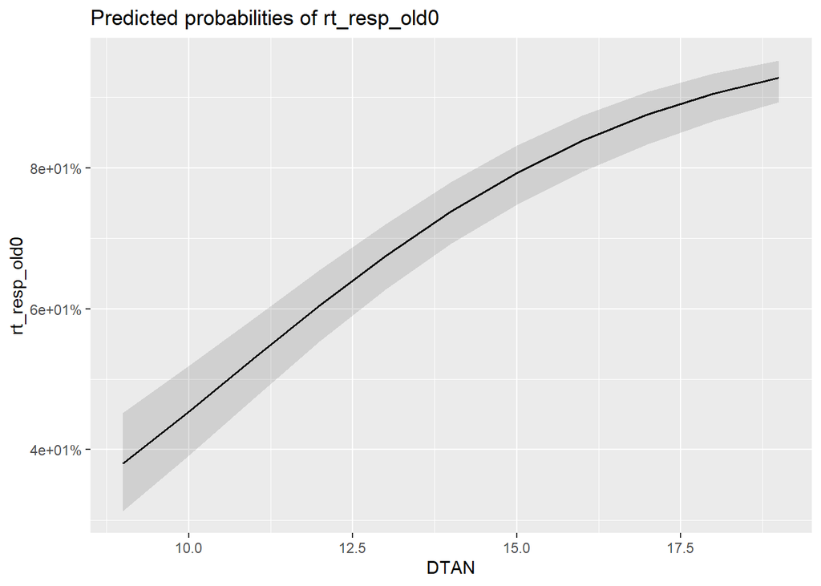

```
## Package `effects` is not available, but needed for `ggeffect()`. Either install package `effects`, or use `ggpredict()`. Calling `ggpredict()` now.FALSE
## Data were 'prettified'. Consider using `terms="DTAN [all]"` to get smooth plots.
```

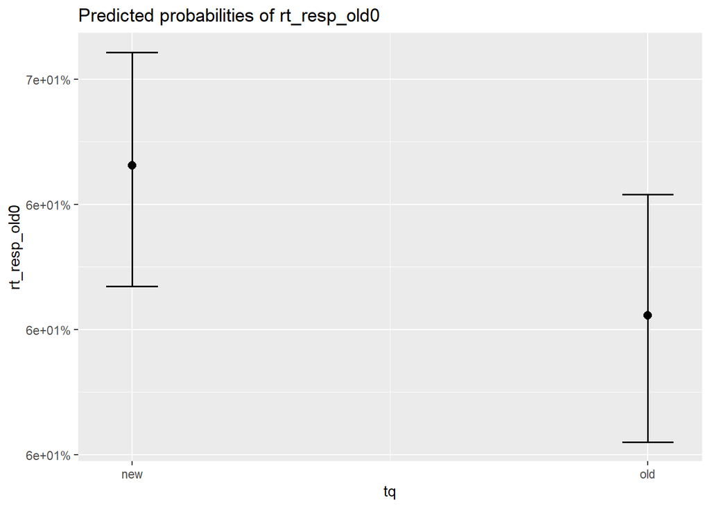

```
## Data were 'prettified'. Consider using `terms="DTAN [all]"` to get smooth plots.
```

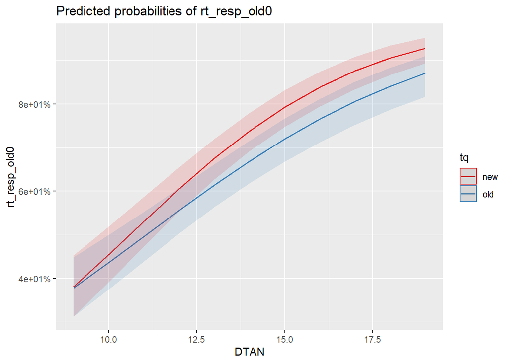

```
## Generalized linear mixed model fit by maximum likelihood (Laplace
##   Approximation) [glmerMod]
##  Family: binomial  ( logit )
## Formula: rt_resp_old0 ~ DTN_byPhase * tq + (1 | workerId)
##    Data: tdlmm
##
##      AIC      BIC   logLik deviance df.resid
##   4420.1   4451.0  -2205.1   4410.1     3571
##
## Scaled residuals:
##     Min      1Q  Median      3Q     Max
## -3.3229 -0.9521  0.4971  0.7609  1.9065
##
## Random effects:
##  Groups   Name        Variance Std.Dev.
##  workerId (Intercept) 0.3744   0.6119
## Number of obs: 3576, groups:  workerId, 44
##
## Fixed effects:
##                   Estimate Std. Error z value Pr(>|z|)
## (Intercept)       -3.12590    0.40010  -7.813 5.59e-15 ***
## DTN_byPhase        0.28587    0.02961   9.653  < 2e-16 ***
## tqold              0.51798    0.53604   0.966    0.334
## DTN_byPhase:tqold -0.05785    0.04057  -1.426    0.154
## ---
## Signif. codes:  0 '***' 0.001 '**' 0.01 '*' 0.05 '.' 0.1 ' ' 1
##
## Correlation of Fixed Effects:
##             (Intr) DTN_bP tqold
## DTN_byPhase -0.964
## tqold       -0.704  0.716
## DTN_byPhs:t  0.701 -0.726 -0.991
```

```
## Package `effects` is not available, but needed for `ggeffect()`. Either install package `effects`, or use `ggpredict()`. Calling `ggpredict()` now.FALSE
```

```
## Data were 'prettified'. Consider using `terms="DTN_byPhase [all]"` to get smooth plots.
```

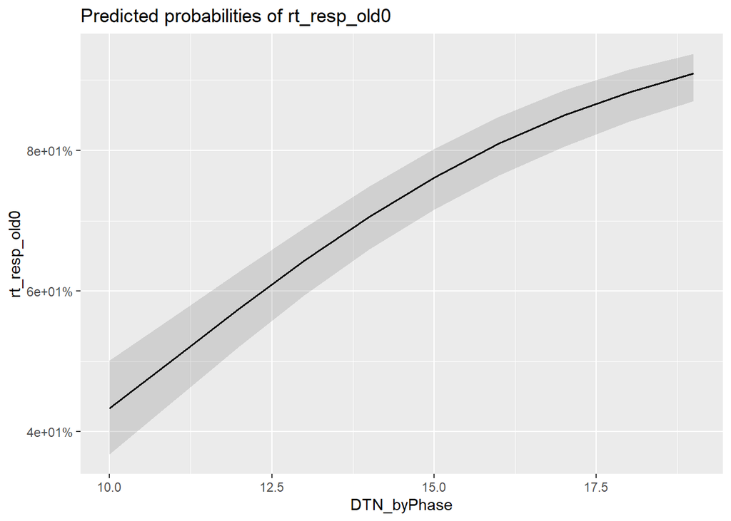

```
## Package `effects` is not available, but needed for `ggeffect()`. Either install package `effects`, or use `ggpredict()`. Calling `ggpredict()` now.FALSE
## Data were 'prettified'. Consider using `terms="DTN_byPhase [all]"` to get smooth plots.
```

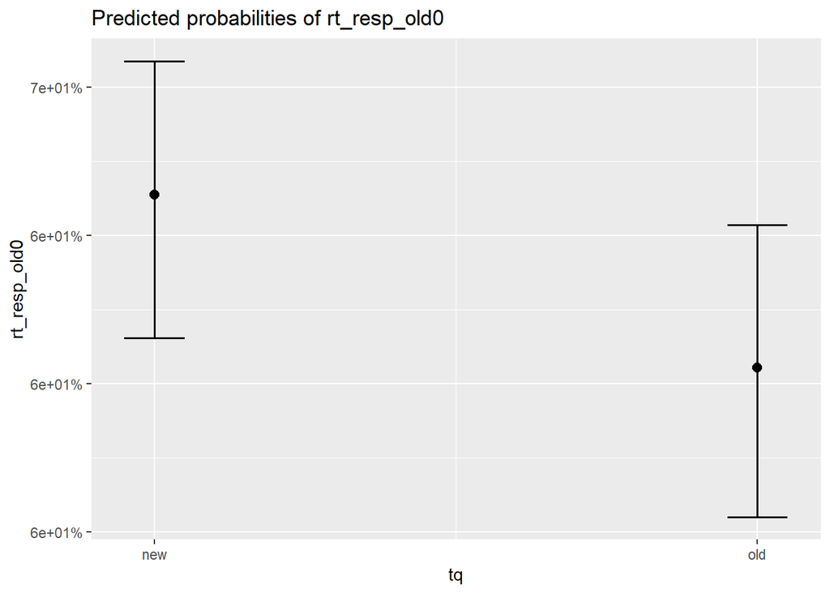

```
## Data were 'prettified'. Consider using `terms="DTN_byPhase [all]"` to get smooth plots.
```

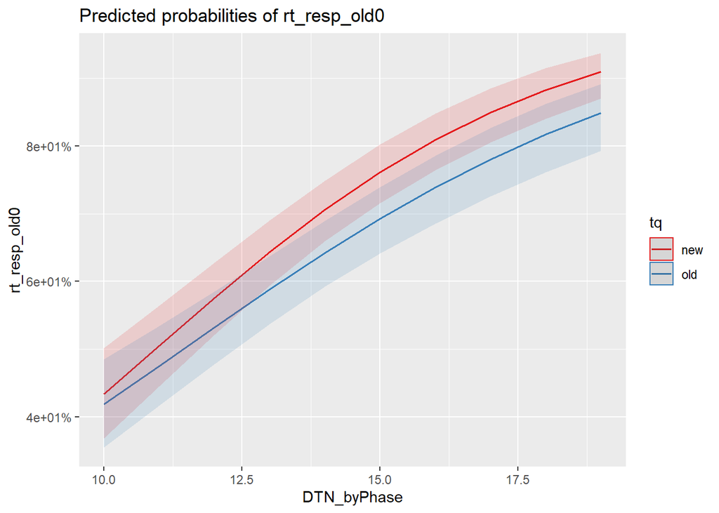

[output not shown]